# Week 5: Estimands

PS 812 - Introduction to Statistical Methods in Political Science

Anton Strezhnev

strezhnev@wisc.edu

University of Wisconsin-Madison

October 6, 2026

## Welcome back!

$$\newcommand{\Var}{\text{Var}}
\newcommand{\Cov}{\text{Cov}}
\newcommand{\Corr}{\text{Corr}}
\newcommand{\indep}{\mathrel{\perp\mkern-10mu\perp}}$$

## Week overview

- Last week
  - Joint and conditional distributions
  - Covariance and correlation
  - Conditional expectations and the best linear predictor
- This week
  - **What is a scientific theory for?**
  - What counts as an **explanation**? Models, interventions, mechanisms
  - **Asking a research question**: What is your estimand?
  - **Descriptive** versus **causal** questions
  - Connecting the theoretical estimand to an **empirical** estimand
- **Midterm** on Wednesday!

## From theory to empirics

[figure not shown]

Adapted from Lundberg et al. (2021), Fig. 1

## One view of scientific theory

- A theory consists of a set of **assumptions**…
- …from which we deductively derive **propositions**…
- …which have **testable implications**.

## The hypothetico-deductive model

1. Formulate a theory
2. Derive empirical implications
3. Test those implications
4. If the implications hold, keep the theory. If they don’t, change the theory.

## The hypothetico-deductive model is a lie

1. Formulate a theory
   - …often *after* seeing the data.
2. Derive empirical implications
   - …which never follow from the theory alone
3. Test those implications
   - …with noisy data and probabilistic predictions
4. If the implications hold, keep the theory. If they don’t, change the theory.
   - …passing doesn’t prove the theory is true and failing doesn’t tell you what to change

## The principle of “falsification”

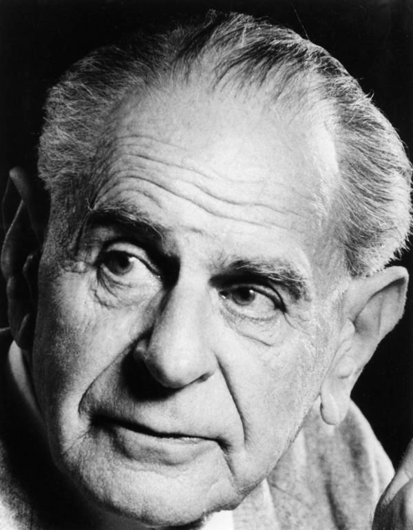

## The principle of “falsification”

- **Popper** ([1935] 1959): Theories cannot be proven **true** but they can be demonstrated to be **false**

  > “In so far as a scientific statement speaks about reality, it must be falsifiable; and in so far as it is not falsifiable, it does not speak about reality.” (Popper [1935] 1959)
- A scientific statement **sets the conditions** under which it could be demonstrated wrong.
  - Is there an experimental finding that would **contradict** a theory’s predictions?

## The problems with falsification alone

- Let’s consider a classic **political science** theory: **Duverger’s Law** (Duverger 1954)
  - **Electoral systems** affect the **number of parties** in that system.
- **Plurality rule** in **single member district** elections $\leadsto$ **two parties**
  - **Proportional** systems lead to **many parties**
- What’s the logic?
  - Voters don’t want to waste their vote on a third party that has no chance of winning.

## The problems with falsification alone

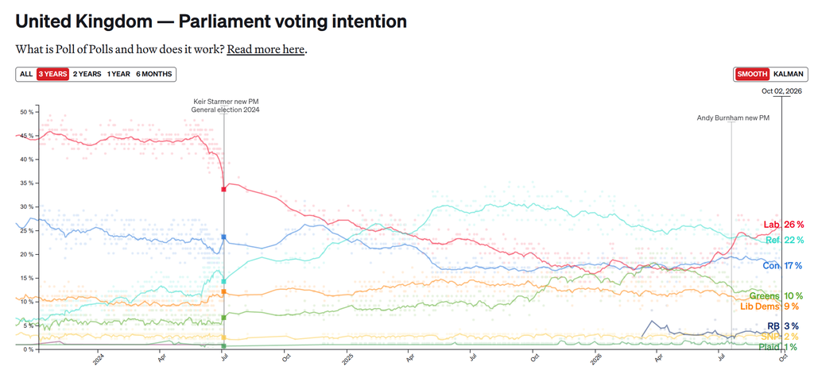

Politico.eu polling average of UK Parliament Voting Intention

## Research programmes

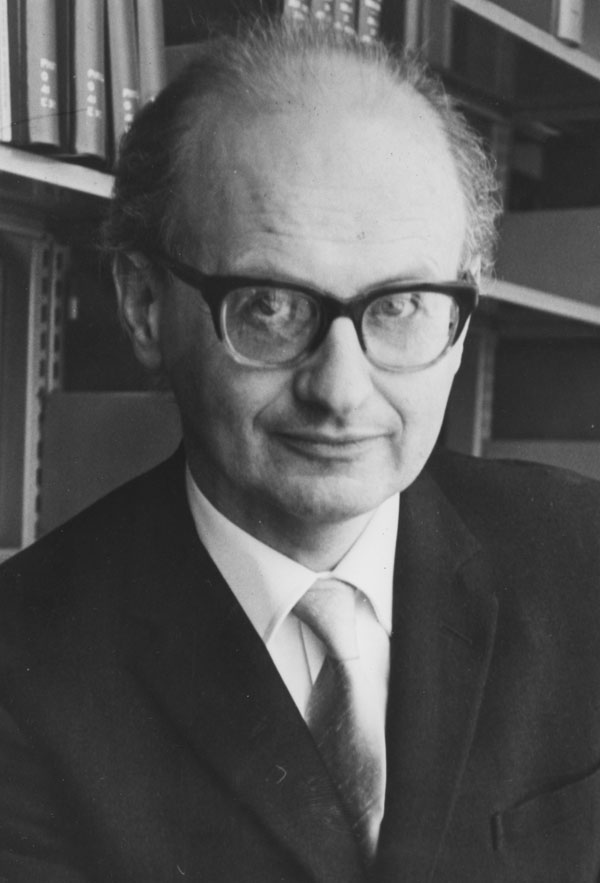

## Research programmes

- **Lakatos** (1970): A **middle ground** between falsificationism and methodological anarchy
- Science is not interested in just a single **theory** - science is built around research **programmes**
  - Democracy and autocracy
  - Voters and elections
  - Political economy
- Theories are built around a **core** of assumptions that are hard to challenge
  - (e.g. rational actor model)
- The core is surrounded by “auxiliary” hypotheses - more open to revision
  - (e.g. voters punish incumbents for bad economic outcomes)
- Findings that go against the theory lead to revisions of **auxiliary** hypotheses
  - (e.g. maybe different economic outcomes matter more - inflation vs. unemployment?)

## Research programmes

- **Productive** research programmes
  - Revisions in the auxiliary hypotheses lead to changes in theories **that generate new, useful predictions**
- **Unproductive** research programmes keep having to add modifications just to stay afloat!

## Back to Duverger’s Law

- Single-member systems don’t consistently get two major parties - **Canada (the BQ), UK (Greens, Lib-Dems, Reform)**
  - Is Duverger’s Law a **bad theory?**
  - Or just in need of **refinement?**
- Do we revise the auxiliary hypotheses
  - (e.g. Can strategic voters create systems with more than two parties under plurality/single member districts?)
- Or do we need to revise the core?
  - (e.g. Voters aren’t strategic!)

## Explaining the UK

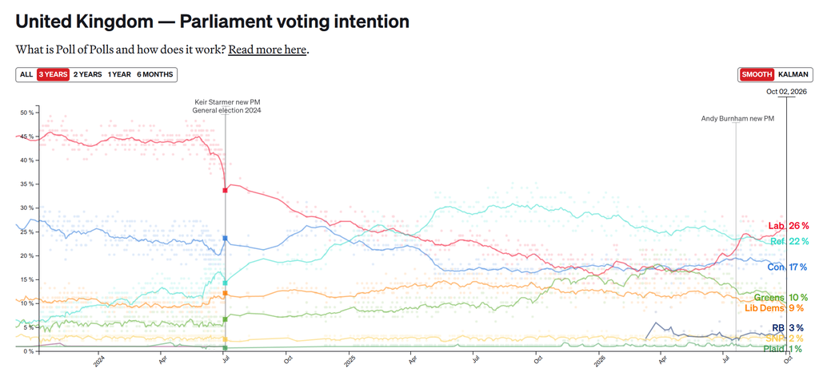

Politico.eu polling average of UK Parliament Voting Intention

## Models don’t have to be true

- “All models are wrong, but some are useful” (Box 1979). A model is a **representation**, for a purpose (Clarke and Primo 2007, 2012)
  - Models serve many purposes beyond prediction.
  - They provide foundational **concepts**, they may articulate structural **constraints** on the world, they may try to **explain** some observed phenomenon.
- Some of the most important models have **no empirical test at all!**
  - **Arrow** (1951): no voting rule satisfies Pareto efficiency, non-dictatorship, and independence of irrelevant alternatives
  - **Fearon** (1995): war is costly, so why can’t rational states find a bargain both prefer?
  - What would it mean to “test” either of these? It’s pointless: these are tools to **guide our thinking**

## “Why does this happen?”

- As social scientists, we don’t just want to **predict**, we want to **explain**.
  - Why do wars happen?
  - Why do democracies collapse?
  - Why is American politics so polarized?
- But what counts as an **answer** to a why-question?
  - **Description** defines the terms of explanation, but it answers a “**What?**” question.
  - **Prediction** is a step forward, but it’s also a “What?” - A **What will?** question.
  - A **model** gives us an interesting story, but why should we believe it?

## From “why?” to “what if?”

- One answer: explanation by **manipulation**
  - To explain is to answer “**what if things had been different?**” (Woodward 2003)
  - Would this country have gone to war if it were a democracy? Would turnout have been higher under same-day registration?
  - These are **causal** questions
- Causes are things you can **intervene** on
  - Whether the story behind the effect is “true” is besides the point.
  - “If you can spray them, then they are real” (Hacking 1983)
- The quantity of interest is **an effect**: the consequence of a manipulable ‘treatment’ on a defined population
  - The theory’s job is to **suggest** plausible manipulations to search over.

## Theory as mechanism-explaining

- But how do we know whether an effect in one setting **generalizes** to other settings?
  - This is often termed an “external validity” or “transportability” question.
  - Is the effect the same if we did the intervention tomorrow? Or in Sweden? Or in the real world and not a survey?
- The **empiricists’** answer: Just run more studies in more places!
- The **theorists’** rebuttal: You can run all the experiments you want, you won’t know the **mechanism**
- **Theory and Credibility** (Ashworth et al. 2021) “‘Why does this important thing happen?’ has been replaced by ‘What is the effect of $x$ on $y$?’” (p. 1)
  - “The essence of formal theory is the crafting of models that **embody mechanisms** and reveal the **all else equal implications** of those mechanisms” (p. 7)
  - “The essence of the credibility revolution is the crafting of research designs that make credible the claim to have **held all else equal**, at least on average” (p. 7)

## Step 1: Set a target

[figure not shown]

Adapted from Lundberg et al. (2021), Fig. 1

## What’s your estimand?

> Every quantitative study must be able to answer the question: **what is your estimand?** The estimand is the target quantity—the purpose of the statistical analysis. Much attention is already placed on how to do estimation; a similar degree of care should be given to defining the thing we are estimating. We advocate that authors **state the central quantity of each analysis**—the theoretical estimand—in precise terms that exist outside of any statistical model. In our framework, researchers do three things: (1) set a theoretical estimand, clearly connecting this quantity to theory; (2) **link to an empirical estimand**, which is informative about the theoretical estimand under some identification assumptions; and (3) **learn from data**.

— Lundberg et al. (2021)

## Types of empirical questions

- **Descriptive** - **“What?”**
  - What is the share of U.S. Hispanic voters who voted for Donald Trump in 2024?
  - How many political posts on Facebook are false information?
  - What is the structure of the co-sponsorship network in the U.S. Congress?
- **Causal** - **What if?** (“Effects of Causes”)
  - Does weakening central bank independence increase inflation?
  - Does changing an individual’s news diet change their attitudes?
  - Does giving someone a guaranteed income affect their willingness to search for employment?

## Estimands as population expectations

- Many theoretical estimands in the social sciences can be articulated in terms of a **unit-specific quantity** plus a **target population** (Lundberg et al. 2021)
  - Stated in terms that “exist outside of any statistical model” rather than as regression coefficients
- For **descriptive** estimands, a common target is the **expectation** of the individual level outcome measure $Y_i$ over some population distribution

  $$\underbrace{\mathbb{E}}_{\substack{\text{average over the} \\ \text{target population}}} \big[\, \underbrace{Y_i}_{\text{unit-specific quantity}} \,\big]$$

## Defining causal estimands

- We need a language for talking about **“What if?”** questions - How do we articulate an estimand for a **causal** quantity?
  - Causation is about manipulation: If a treatment $D$ were changed, what would happen to $Y$?
- The **potential outcomes** framework (Rubin 1974)
  - Units $i$ in some population
  - A binary **treatment** $D_i \in \{0, 1\}$
  - An observed **outcome** $Y_i$
- The **potential outcome** $Y_i(d)$ is the value $Y_i$ would take if $D_i$ were **set** to $d$
  - $Y_i(1)$: the outcome if unit $i$ were treated
  - $Y_i(0)$: the outcome if unit $i$ were under control
  - Each unit has **both**. They are fixed attributes.
  - “Potential” because we **only** get to see one.

## Causal effects are contrasts in potential outcomes

- The **individual** causal effect: $\tau_i = Y_i(1) - Y_i(0)$
- The **average treatment effect** (ATE): the same unit-specific quantity, averaged over a target population

  $$\tau = \underbrace{\mathbb{E}}_{\substack{\text{average over the} \\ \text{target population}}} \big[\, \underbrace{Y_i(1) - Y_i(0)}_{\text{unit-specific causal effect}} \,\big] = \mathbb{E}[Y_i(1)] - \mathbb{E}[Y_i(0)]$$
- Changing the **target population** changes the estimand.
  - The **ATT**, the effect among those who were treated: $\mathbb{E}[Y_i(1) - Y_i(0) \mid D_i = 1]$
  - Conditional effects among women vs. men, among those who would comply with treatment…
- All of this exists **outside of any statistical model**. No regressions yet!

## The fundamental problem of causal inference

- We only ever observe the potential outcome for the treatment that was **actually** received

  $$Y_i = Y_i(1)\, D_i + Y_i(0)\, (1 - D_i)$$

| Unit $i$ | Treatment $D_i$ | $Y_i(1)$ | $Y_i(0)$ | Observed $Y_i$ |
| --- | --- | --- | --- | --- |
| $1$ | $1$ | $5$ | ? | $5$ |
| $2$ | $0$ | ? | $-3$ | $-3$ |
| $3$ | $1$ | $9$ | ? | $9$ |
| $\vdots$ | $\vdots$ | $\vdots$ | $\vdots$ | $\vdots$ |
| $N$ | $0$ | ? | $8$ | $8$ |

- Half the table is **missing**, by construction. No $\tau_i$ is ever observed (Holland 1986)
- So the theoretical estimand $\mathbb{E}[Y_i(1)] - \mathbb{E}[Y_i(0)]$ is defined on quantities we **can’t see**
- What assumptions can we make on the way the data is generated so that we **can** see it?

## Step 2: Link to observable data

[figure not shown]

Adapted from Lundberg et al. (2021), Fig. 1

## Causal Identification

- The **theoretical** estimand is defined in terms of potential outcomes: $\tau = \mathbb{E}[Y_i(1)] - \mathbb{E}[Y_i(0)]$
- An **empirical** estimand is defined on things we observe.
- One choice: The **difference** in **conditional expectations** between treated and control

  $$\mathbb{E}[Y_i \mid D_i = 1] - \mathbb{E}[Y_i \mid D_i = 0]$$
- **Identification**: under what assumptions about the world are these two the **same number**?
  - This comes *before* any question about estimation.

## Causal Identification

- We assume that $Y_i = Y_i(1)$ when $D_i = 1$ and $Y_i = Y_i(0)$ when $D_i = 0$:

  $$\mathbb{E}[Y_i \mid D_i = 1] - \mathbb{E}[Y_i \mid D_i = 0] = \mathbb{E}[Y_i(1) \mid D_i = 1] - \mathbb{E}[Y_i(0) \mid D_i = 0]$$
- And so the empirical estimand is equal to the treated group’s $Y_i(1)$ minus the control group’s $Y_i(0)$
  - This is a comparison of two causal quantities but it’s **not on the same set** of units!
- One way to think about the discrepancy is in terms of how the **difference-in-means** differs from the average treatment effect **on the treated**

  $$\underbrace{\mathbb{E}[Y_i \mid D_i = 1] - \mathbb{E}[Y_i \mid D_i = 0]}_{\text{difference in means}} = \underbrace{\mathbb{E}[Y_i(1) - Y_i(0) \mid D_i = 1]}_{\text{ATT}} + \underbrace{\mathbb{E}[Y_i(0) \mid D_i = 1] - \mathbb{E}[Y_i(0) \mid D_i = 0]}_{\text{selection into treatment bias}}$$
- **Selection into treatment bias**: How different are the treated and control groups’ outcomes **even without** treatment?

## Ignorability

- The assumption that makes the selection bias **zero**: treatment is independent of the potential outcomes

  $$\{Y_i(1), Y_i(0)\} \indep D_i$$
  - Also called **unconfoundedness**, **exogeneity**, “as-if random”
  - In words: treatment is not systematically more likely for units with higher (or lower) potential outcomes
- Then $\mathbb{E}[Y_i(0) \mid D_i = 1] = \mathbb{E}[Y_i(0) \mid D_i = 0]$, and the difference in means **identifies** the ATE

  $$\mathbb{E}[Y_i \mid D_i = 1] - \mathbb{E}[Y_i \mid D_i = 0] = \mathbb{E}[Y_i(1)] - \mathbb{E}[Y_i(0)]$$
- **Randomized experiments** make this true by design.
  - In observational data it is an **assumption about the world**

## Conditional ignorability

- A weaker assumption states that treatment is as-if random **within** groups defined by observed covariates $X_i$

  $$\{Y_i(1), Y_i(0)\} \indep D_i \mid X_i \qquad\qquad 0 < P(D_i = 1 \mid X_i) < 1$$
  - “Selection on observables”, “no unmeasured confounders”
- Then the **empirical estimand** is the average, over $X$, of the within-$X_i$ differences in means

  $$\tau = \mathbb{E}_X\Big[\, \mathbb{E}[Y_i \mid D_i = 1, X_i] - \mathbb{E}[Y_i \mid D_i = 0, X_i] \,\Big]$$
- This is what **assumptions** get us!
  - Which $X_i$? That’s where we need theory and prior evidence to guide our choices.

## Identification vs. estimation

- **Identification** assumptions: what must be true of the **world** for an observable quantity to equal the estimand
  - Ignorability, conditional ignorability, consistency, positivity
  - Determined by argument, research design and **substantive knowledge**
- **Estimation** assumptions: what we need to learn that observable quantity from a **finite sample**
  - $\mathbb{E}[Y_i \mid D_i = 1, X_i]$ is a population quantity. We have $N$ observations, and maybe few at each value of $X_i$
  - This is where the statistical models come in.
- Incorrect estimation assumptions add bias **even if** identification holds.
  - But getting identification wrong means no amount of fancy stats can save you.

## Step 3: Learn from data

[figure not shown]

Adapted from Lundberg et al. (2021), Fig. 1

## Next week

- **Step 3**: Learning from the data!
  - Where does the randomness come from?
  - Estimators as functions of data: they are **random variables**!
  - Sampling distributions
  - Bias, variance and other properties of an estimator.

## References

Arrow, Kenneth J. 1951. *Social Choice and Individual Values*. Wiley.

Ashworth, Scott, Christopher R. Berry, and Ethan Bueno de Mesquita. 2021. *Theory and Credibility: Integrating Theoretical and Empirical Social Science*. Princeton University Press.

Box, George E. P. 1979. “Robustness in the Strategy of Scientific Model Building.” In *Robustness in Statistics*, edited by Robert L. Launer and Graham N. Wilkinson. Academic Press.

Clarke, Kevin A., and David M. Primo. 2007. “Modernizing Political Science: A Model-Based Approach.” *Perspectives on Politics* 5 (4): 741–53. https://doi.org/10.1017/S1537592707072192.

Clarke, Kevin A., and David M. Primo. 2012. *A Model Discipline: Political Science and the Logic of Representations*. Oxford University Press.

Duverger, Maurice. 1954. *Political Parties: Their Organization and Activity in the Modern State*. Methuen.

Fearon, James D. 1995. “Rationalist Explanations for War.” *International Organization* 49 (3): 379–414. https://doi.org/10.1017/S0020818300033324.

Hacking, Ian. 1983. *Representing and Intervening: Introductory Topics in the Philosophy of Natural Science*. Cambridge University Press.

Holland, Paul W. 1986. “Statistics and Causal Inference.” *Journal of the American Statistical Association* 81 (396): 945–60. https://doi.org/10.1080/01621459.1986.10478354.

Lakatos, Imre. 1970. “Falsification and the Methodology of Scientific Research Programmes.” In *Criticism and the Growth of Knowledge*, edited by Imre Lakatos and Alan Musgrave. Cambridge University Press.

Lundberg, Ian, Rebecca Johnson, and Brandon M. Stewart. 2021. “What Is Your Estimand? Defining the Target Quantity Connects Statistical Evidence to Theory.” *American Sociological Review* 86 (3): 532–65. https://doi.org/10.1177/00031224211004187.

Popper, Karl R. (1935) 1959. *The Logic of Scientific Discovery*. Hutchinson.

Rubin, Donald B. 1974. “Estimating Causal Effects of Treatments in Randomized and Nonrandomized Studies.” *Journal of Educational Psychology* 66 (5): 688–701. https://doi.org/10.1037/h0037350.

Woodward, James. 2003. *Making Things Happen: A Theory of Causal Explanation*. Oxford University Press.